# CH3 : Logistic Regression

TP4

> In this PW we are going to analyse the `Social_Network_Ads` dataset. This dataset contains informations of users of a social network. The social network has several business clients and its business clients put ads on the social network for marketing compaigns purposes. For this dataset, a company has put ads for one of its new products and the social network gathered some informations about wich users responded positively to the ad by buying the product and those who responded negatively by not buying the product.

# Question 1

Import the `Social_Network_Ads` dataset into `R`

```r
dataset = read.csv("/Users/steven/Documents/ESILV A4/Machine Learning/TP4/Social_Network_Ads.csv")
```

# Question 2

Describe the dataset (you can use `str()` and `summary()` functions).

```r
str(dataset)
```

```
## 'data.frame':    400 obs. of  5 variables:
##  $ User.ID        : int  15624510 15810944 15668575 15603246 15804002 15728773 15598044 15694829 15600575 15727311 ...
##  $ Gender         : chr  "Male" "Male" "Female" "Female" ...
##  $ Age            : num  19 35 26 27 19 27 27 32 25 35 ...
##  $ EstimatedSalary: num  19000 20000 43000 57000 76000 58000 84000 150000 33000 65000 ...
##  $ Purchased      : int  0 0 0 0 0 0 0 1 0 0 ...
```

```r
summary(dataset)
```

```
##     User.ID            Gender               Age        EstimatedSalary
##  Min.   :15566689   Length:400         Min.   :18.00   Min.   : 15000
##  1st Qu.:15626764   Class :character   1st Qu.:29.75   1st Qu.: 43000
##  Median :15694342   Mode  :character   Median :37.00   Median : 70000
##  Mean   :15691540                      Mean   :37.66   Mean   : 69742
##  3rd Qu.:15750363                      3rd Qu.:46.00   3rd Qu.: 88000
##  Max.   :15815236                      Max.   :60.00   Max.   :150000
##    Purchased
##  Min.   :0.0000
##  1st Qu.:0.0000
##  Median :0.0000
##  Mean   :0.3575
##  3rd Qu.:1.0000
##  Max.   :1.0000
```

> We will consider the variables Age and EstimatedSalary as input variables (features) to see the correlations between them and the decision of the user to buy (or not) the product

# Question 3

Now we are going to split the dataset into training set and test set. Last week we did it manually. From now on split it randomly with caTools packages

```r
library(caTools) # install it first in the console
set.seed(123) # we use this function with the same number to randomly generate the same values

split = sample.split(dataset$Purchased, SplitRatio = 0.75)

#training_data = dataset[split,]
#testing_data = dataset[-split,]
training_data = subset(dataset, split == TRUE)
testing_data = subset(dataset, split == FALSE)
str(training_data)
```

```
## 'data.frame':    300 obs. of  5 variables:
##  $ User.ID        : int  15624510 15668575 15728773 15598044 15694829 15727311 15570769 15746139 15704987 15628972 ...
##  $ Gender         : chr  "Male" "Female" "Male" "Female" ...
##  $ Age            : num  19 26 27 27 32 35 26 20 32 18 ...
##  $ EstimatedSalary: num  19000 43000 58000 84000 150000 65000 80000 86000 18000 82000 ...
##  $ Purchased      : int  0 0 0 0 1 0 0 0 0 0 ...
```

# Question 4

Scale the input variables in both training set and test set.

```r
training_data[, 3:4] = scale(training_data[, 3:4])
testing_data[, 3:4] = scale(testing_data[, 3:4])
summary(training_data)
```

```
##     User.ID            Gender               Age           EstimatedSalary
##  Min.   :15566689   Length:300         Min.   :-1.86115   Min.   :-1.58750
##  1st Qu.:15635990   Class :character   1st Qu.:-0.71387   1st Qu.:-0.78838
##  Median :15697499   Mode  :character   Median :-0.04462   Median : 0.01075
##  Mean   :15695168                      Mean   : 0.00000   Mean   : 0.00000
##  3rd Qu.:15753864                      3rd Qu.: 0.72024   3rd Qu.: 0.49593
##  Max.   :15815236                      Max.   : 2.15435   Max.   : 2.26543
##    Purchased
##  Min.   :0.0000
##  1st Qu.:0.0000
##  Median :0.0000
##  Mean   :0.3567
##  3rd Qu.:1.0000
##  Max.   :1.0000
```

# Question 5

Fit a simple logistic regression model of `Purchased` in function of `Age`

```r
model1 = glm(Purchased~Age, data = training_data,family=binomial)
summary(model1)
```

```
##
## Call:
## glm(formula = Purchased ~ Age, family = binomial, data = training_data)
##
## Deviance Residuals:
##     Min       1Q   Median       3Q      Max
## -2.5341  -0.6641  -0.2950   0.5437   2.4392
##
## Coefficients:
##             Estimate Std. Error z value Pr(>|z|)
## (Intercept)  -0.9299     0.1672  -5.562 2.67e-08 ***
## Age           1.9913     0.2342   8.502  < 2e-16 ***
## ---
## Signif. codes:  0 '***' 0.001 '**' 0.01 '*' 0.05 '.' 0.1 ' ' 1
##
## (Dispersion parameter for binomial family taken to be 1)
##
##     Null deviance: 390.89  on 299  degrees of freedom
## Residual deviance: 252.11  on 298  degrees of freedom
## AIC: 256.11
##
## Number of Fisher Scoring iterations: 5
```

# Question 6

In the argument `family` of the function `glm` we chose `binomial`. Why ?

```r
#In order to tell R to do a logistic regression, rather then some other type of generalised linear regression
#We chose binomial because the outcome is between 0 and 1.
```

# Question 7

What is the equation of the obtained model in the question 1.5 ?

```r
#Y = 1 + 1/exp(B1 X + B0) (using summary(model1))
#Y : Purchased,  X : Age,  B1 = 1.9913 ,  B0 = -0.9299
```

# Question 8

Is the feature `Age` significant?

```r
#If abs(coefficient) > 0, here B1 = 1.9913 and p-value 2e-16 (< 0.05) : mean age is significant
```

The `AIC` is the `Akaike Information Criterion`. You will use this while comparing multiple models. The model with lower value of `AIC` is better. Suppose that we have a statistical model of some data. Let $L$ be the maximum value of the likelihood function for the model; let `k` be the number of estimated parameters in the model. Then the `AIC` value of the model is the following.

$AIC=2k−2ln(L)$

where

- $L$ = the maximized value of the likelihood function of the model $M$, i.e. $L=p(x|β,M)$, where $β$ are the parameter values that maximize the likelihood function.
- x= the observed data.
- k= the number of free parameters to be estimated. If the model under consideration is a linear regression, k is the number of regressors, including the intercept.

# Question 9

What is the value of AIC of the model

```r
#(using summary(model1))
#AIC: 256.11
```

# Question 10

Plot `Purchased` in function of `Age` and add the curve of the obtained logistic regression model.

(Hints: First plot the point, then use the `curve()` function with option `add=TRUE` to add the curve to the plot. The argument `type` of the function `predit()` must be `reponse`)

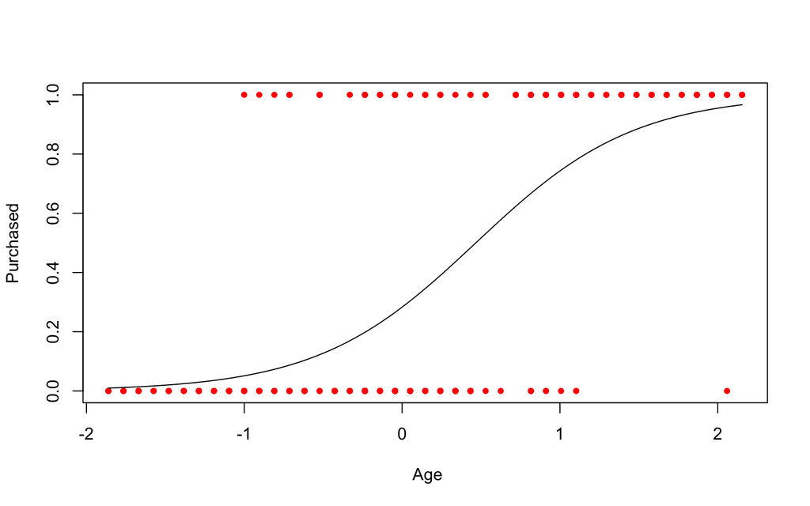

```r
plot(training_data$Age, training_data$Purchased,
xlab = " Age",
ylab = "Purchased",
col = "red",
pch = 20)
curve(predict(model1, data.frame(Age=x), type="response"), add=TRUE)
```

# Question 11

Now let us take another feature into account in the model. Fit a logistic regression model of `purchasing` the product in function of the `age` of the user and its `salary`.

```r
model2 = glm(Purchased~Age+EstimatedSalary, data = training_data,family=binomial)
summary(model2)
```

```
##
## Call:
## glm(formula = Purchased ~ Age + EstimatedSalary, family = binomial,
##     data = training_data)
##
## Deviance Residuals:
##     Min       1Q   Median       3Q      Max
## -3.0753  -0.5235  -0.1161   0.3224   2.3977
##
## Coefficients:
##                 Estimate Std. Error z value Pr(>|z|)
## (Intercept)      -1.1923     0.2018  -5.908 3.47e-09 ***
## Age               2.6324     0.3461   7.606 2.83e-14 ***
## EstimatedSalary   1.3947     0.2326   5.996 2.03e-09 ***
## ---
## Signif. codes:  0 '***' 0.001 '**' 0.01 '*' 0.05 '.' 0.1 ' ' 1
##
## (Dispersion parameter for binomial family taken to be 1)
##
##     Null deviance: 390.89  on 299  degrees of freedom
## Residual deviance: 199.78  on 297  degrees of freedom
## AIC: 205.78
##
## Number of Fisher Scoring iterations: 6
```

# Question 12

Are the predictors significant? Did the model get better by adding the estimated salary?

```r
#model equation : Y = 1 + 1/exp(b0 + b1 X1 + b2 X2)

#Y : Purchased,  X1 = Age, X2 = Estimated salary; b0 = -1.1923,  b1 = 2.6324, b2 = 1.3947

#Age p-value : 2.83e-14
#Estimated salary p-value : 2.03e-09

#Both b1 and b2 are (> 0) and in particular (> 1), both p-value are small (< 0.05) : predictors significant

#Yes, the model get better since AIC: 205.78 (< 256.11)
```

# Question 13

Did the model get better by adding the estimated salary?

```r
#Yes, the model get better since AIC: 205.78 (< 256.11)
```